# Simulations OVB/type M trade-off: RDD

Vincent Bagilet https://www.sipa.columbia.edu/experience-sipa/sipa-profiles/vincent-bagilet (Columbia University)https://www.columbia.edu/ , Léo Zabrocki https://www.parisschoolofeconomics.eu/en/ (Paris School of Economics)https://www.parisschoolofeconomics.eu/en/  
2021-10-25

## Purpose of the document

In this document, we run a simulation exercise to illustrate the existence of a trade-off between Omitted Variable Bias (OVB) and type M error in the context of a Regression Discontinuity Design (RDD). This trade-off is mediated by the size of the bandwidth considered in the analysis. The underlying idea is that the smaller the bandwidth, the more comparable units are and therefore the smaller the risk of OVB is. Yet, with a smaller bandwidth, sample size and thus power decrease, increasing type M error.

## An illustrative example

To illustrate this trade-off between OVB and type M error, we consider a standard application of the RD design in economics of education where an grant or additional lessons are assigned based on the score obtained by students on a standardized test. Students with test scores below a given threshold receive the treatment while those above do not. Yet, students far above and far below the threshold may differ along unobserved characteristics such as ability. To limit this bias, the effect of the treatment is estimated by comparing the outcomes of students just below and just above this threshold. This enable to limit disparities in terms of unobserved characteristics.

[Thistlewaite and Campbell (1960)](https://psycnet.apa.org/record/1962-00061-001) introduced the concept of RDD using this type of quasi-experiment. In their paper, they take advantage of a sharp discontinuity in the assignment of an award (a Certificate of Merit) based on qualifying scores at a test. This type of analysis is still used today and many papers leveraging similar methodologies have been published since this seminal work. For instance, [Jacob and Lefgren (2004)](https://direct.mit.edu/rest/article/86/1/226/57489/Remedial-Education-and-Student-Achievement-A) exploit this type of discontinuity to study the impact of summer school and grade retention programs on test scores. Students who score below a given score are required to attend a summer school and to retake the test. Students who do not pass the second have to repeat the grade.

### Modelisation choices

In the present analysis, we build our simulations to replicate a similar type of quasi-experiment. In our fictional example, all students scoring below a cutoff $C$ in a qualification test are required to take additional lessons. We want to estimate the effect of these additional lessons on scores on a final test taken by all students a year later.

We assume that the final score of student $i$, $Final_i$, is correlated with their qualification score $Qual_i$ and their treatment status $T_i$, *ie* whether student $i$ received additional lessons or not. We further assume that both qualification and final test scores are affected by students’ unobserved ability $U_i$ in a non linear way.

The DGP can be represented using the following Directed Acyclic Graph (DAG):

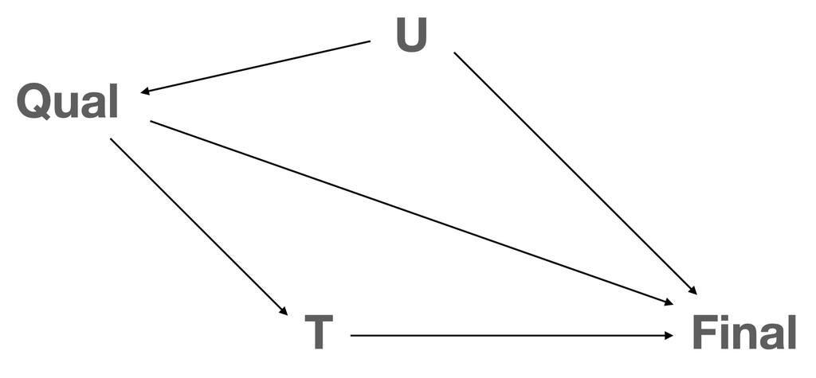

Final test scores are thus defined as follows:

$$Final_{i} = \alpha + \beta T_i + \gamma Qual_{i} + \delta f(U_i) + \epsilon_{i}$$
Where $\alpha$ is a constant, $f$ a non linear function and $e \sim \mathcal{N}(0, \sigma_{e})$ noise. The parameter of interest is $\beta$. Translating this into a potential outcomes framework, we have $Final_i(0) = \alpha + \gamma Qual_{i} + \delta f(U_i) + \epsilon_{i}$ and $Final_i(1) = \alpha + \gamma Qual_{i} + \beta + \delta f(U_i) + \epsilon_{i}$

### Data generation

We write a simple function that generates the data. It takes as input the values of the different parameters and returns a data frame containing all the variables for this analysis. We set baseline values for the parameters to emulate a somehow realistic observational study in this field. The set of parameters may produce test score outside of the range 0-100 in some iterations but that does not affect the analysis.

Once the fake data is generated, to make things more realistic we consider our data as if it was actual data. We do not take advantage of our knowledge of the data generating process in the estimation procedure. However, we observe both potential outcomes and the unobserved ability. Note that, in a real world setting, one would generally know the value of the threshold (and thus of $q_c$). Based on that and to simplify the computation of the bandwidth, we store $q_c$.

```r
generate_data_rdd <- function(N = 1000,
                              sigma_u = 1,
                              mu_h = 0,
                              sigma_h = 1,
                              sigma_e = 1,
                              alpha = 1,
                              beta = 1,
                              gamma = 0.3,
                              delta = 2,
                              q_c = 0.5
                              ) {

  data <- tibble(id = 1:N) %>%
    mutate(
      u = rnorm(nrow(.), 0, sigma_u),
      qual = rnorm(nrow(.), mu_h, sigma_h) + delta*u^2,
      e = rnorm(nrow(.), 0, sigma_e),
      # qual_c = qual - quantile(qual, q_c),
      # treated = qual_c < 0,
      # threshold = quantile(qual, q_c),
      treated = qual < quantile(qual, q_c),
      final0 = alpha + gamma*qual + delta*u^2 + e,
      final1 = final0 + beta,
      final = final0 + beta*treated,
      q_c = q_c
    )

  return(data)
}
```

Here is an example of data created through this process:

| id | u | qual | e | treated | final0 | final1 | final | q_c |
| --- | --- | --- | --- | --- | --- | --- | --- | --- |
| 1 | -2.5357423 | 11.6640997 | -2.0150869 | FALSE | 15.344121 | 16.344121 | 15.344121 | 0.5 |
| 2 | -0.3500630 | -0.2684745 | 0.8808713 | TRUE | 2.045417 | 3.045417 | 3.045417 | 0.5 |
| 3 | 1.0593229 | 3.4431443 | 0.1756556 | FALSE | 4.452929 | 5.452929 | 4.452929 | 0.5 |
| 4 | 0.9764337 | 1.2701529 | -1.0375975 | FALSE | 2.250294 | 3.250294 | 2.250294 | 0.5 |
| 5 | -0.6690987 | -1.0651784 | -0.7992037 | TRUE | 0.776629 | 1.776629 | 1.776629 | 0.5 |
| 6 | 0.8104428 | 1.3811930 | 0.5755390 | FALSE | 3.303532 | 4.303532 | 3.303532 | 0.5 |
| 7 | 0.6534344 | -0.0589802 | -0.7954419 | TRUE | 1.040817 | 2.040817 | 2.040817 | 0.5 |
| 8 | -1.0703568 | 2.6170237 | -0.4950193 | FALSE | 3.581415 | 4.581415 | 3.581415 | 0.5 |
| 9 | -1.0063804 | 0.4536129 | 0.6393728 | TRUE | 3.801060 | 4.801060 | 4.801060 | 0.5 |
| 10 | 0.5853523 | -0.1119826 | -0.2357481 | TRUE | 1.415932 | 2.415932 | 2.415932 | 0.5 |

### Defining the bandwidth

In a RDD, the model is estimated only for observations close enough to the threshold, *ie* in a given bandwidth. We therefore create a function to define this bandwidth by adding a variable to the data set `treated_bw` that is equal to `NA` if the observations is outside of the bandwidth, `TRUE` if the observation falls in the bandwidth and the student is treated and `FALSE` if the observation falls in the bandwidth and the student is not treated. The bandwidth parameter `bw` represents the proportion of units that are in the bandwidth. If `bw = 0.1`, 10% of the students are in the bandwidth for instance.

```r
define_bw <- function (data, bw = 0.1) {
  data <- data %>%
    mutate(
      treated_bw = ifelse(
        dplyr::between(
          qual,
          quantile(qual, unique(q_c) - bw/2),
          quantile(qual, unique(q_c) + bw/2)
        ),
        treated,
        NA
      )
    )
}
```

The following graph illustrates this process by plotting final test scores against qualification ones depending on the value of `treated_bw`.

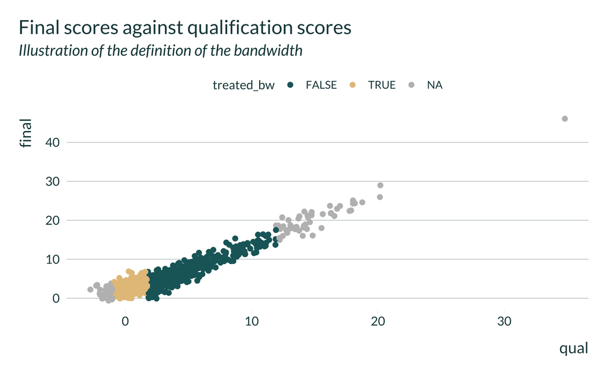

### Estimation

After generating the data, we can run an estimation.

Note that to run power calculations, we need to have access to the true effects. Therefore, before running the estimation, we write a short function to compute the average treatment effect on the treated (ATET). We will add this information to the estimation results.

```r
compute_true_effect_rdd <- function(data) {
  treated_data <- data %>%
    filter(treated)
  return(mean(treated_data$final1 - treated_data$final0))
}
```

```r
estimate_rdd <- function(data, bw) {
  data_in_bw <- data %>%
    define_bw(bw = bw) %>%
    filter(!is.na(treated_bw))

  reg <- lm(
    data = data_in_bw,
    formula = final ~ treated + qual
  ) %>%
  broom::tidy() %>%
  filter(term == "treatedTRUE") %>%
  rename(p_value = p.value, se = std.error) %>%
  select(estimate, p_value, se) %>%
  mutate(true_effect = compute_true_effect_rdd(data))

  return(reg)
}
```

### One simulation

We can now run a simulation, combining `generate_data_rdd` and `estimate_rdd`. To do so we create the function `compute_simulation_rdd`. This simple function takes as input the various parameters along with the bandwidth size, `bw`. It returns a table with the estimate of the treatment, its p-value and standard error, the true effect and the bandwidth and intensity of the OVB considered (delta). Note for now, that we do not store the values of the other parameters for simplicity because we consider them fixed over the study.

```r
compute_simulation_rdd <- function(N = 500,
                              sigma_u = 1,
                              mu_h = 0,
                              sigma_h = 1,
                              sigma_e = 0.5,
                              alpha = 1,
                              beta = 1,
                              gamma = 0.7,
                              delta = 1,
                              q_c = 0.5,
                              bw = 0.1) {
  generate_data_rdd(
    N = N,
    sigma_u = sigma_u,
    mu_h = mu_h,
    sigma_h = sigma_h,
    sigma_e = sigma_e,
    alpha = alpha,
    beta = beta,
    gamma = gamma,
    delta = delta,
    q_c = q_c
  ) %>%
  estimate_rdd(bw = bw) %>%
  mutate(
    bw = bw,
    delta = delta
  )
}
```

Here is an example of an output of this function.

| estimate | p_value | se | true_effect | bw | delta |
| --- | --- | --- | --- | --- | --- |
| 1.469415 | 1.5e-06 | 0.2666136 | 1 | 0.1 | 1 |

### All simulations

We will run the simulations for different sets of parameters by mapping our `compute_simulation_rdd` function on each set of parameters. We thus create a table with all the values of the parameters we want to test `param_rdd`. Note that in this table each set of parameters appears `n_iter` times as we want to run the analysis $n_{iter}$ times for each set of parameters.

```r
# vect_bw <- seq(0.05, 0.4, 0.05)
vect_bw <- c(seq(0.05, 0.4, 0.05), seq(0.4, 1, 0.1))
vect_delta <- c(3)
n_iter <- 1000

param_rdd <- crossing(vect_bw, vect_delta) %>%
  rename(bw = vect_bw, delta = vect_delta) %>%
  crossing(rep_id = 1:n_iter) %>%
  select(-rep_id)
```

We then run the simulations by mapping our `compute_simulation_rdd` function on `param_rdd`.

```r
tic()
simulations_rdd <- pmap_dfr(param_rdd, compute_simulation_rdd)
beep()
toc()

# saveRDS(simulations_rdd, here("Outputs/simulations_rdd.RDS"))
```

## Analysis of the results

### Quick exploration

First, we quickly explore the results.

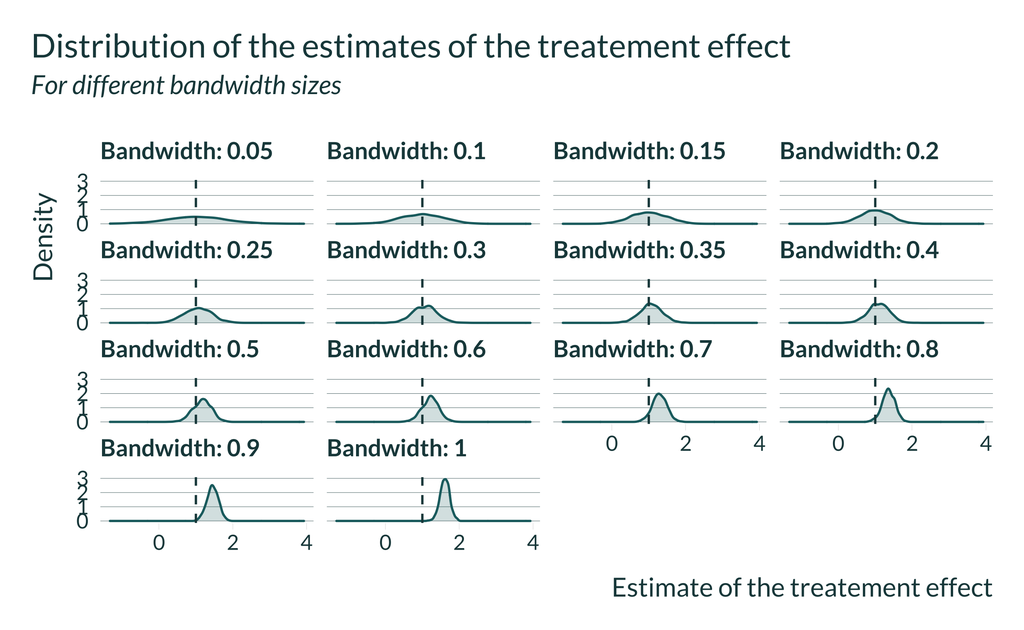

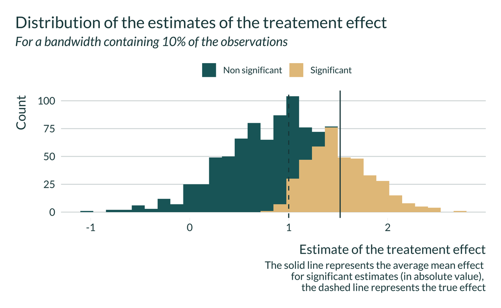

### Computing bias and type M

We want to compare $\mathbb{E}[\beta_0 - \widehat{\beta_{RDD}}]$ and $\mathbb{E}[|\beta_0 - \widehat{\beta_{RDD}}||signif]$. The first term represents the bias and the second term represents the type M error. This terms depend on the effect size. To enable comparison across simulation and getting terms independent of effect sizes, we also compute the average of the ratios between the estimate and the true effect, conditional on significance.

```r
summarise_simulations <- function(data) {
  data %>%
    mutate(significant = (p_value <= 0.05)) %>%
    group_by(delta, bw) %>%
    summarise(
      power = mean(significant, na.rm = TRUE)*100,
      type_m = mean(ifelse(significant, abs(estimate - true_effect), NA), na.rm = TRUE),
      bias_sign = mean(ifelse(significant, estimate/true_effect, NA), na.rm = TRUE),
      bias_all = mean(estimate/true_effect, na.rm = TRUE),
      .groups  = "drop"
    ) %>%
    ungroup()
}

summary_simulations_rdd <- summarise_simulations(simulations_rdd)
# saveRDS(summary_simulations_rdd, here("Outputs/summary_simulations_rdd.RDS"))
```

### Graph

To analyze our results, we build a unique and simple graph:

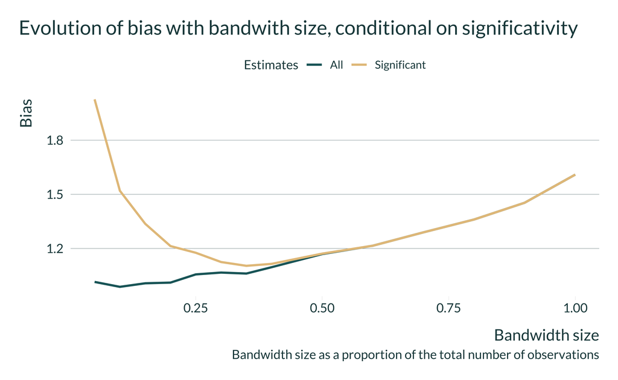